# Empathy in Real vs. Synthetic Clinician Comments

## Summary

Real comments score meaningfully higher than synthetic ones on **Explorations** (4.6x on average; significant for all 3 methods, Kruskal-Wallis p = 0.00032). **Emotional Reactions** and **Interpretations** show no significant real-vs-synthetic differences after correction (0/3 and 0/3 methods respectively). Effect sizes are modest throughout (rank-biserial r = -0.01-0.15), and comment length does not appear to be a general driver of these differences.

## Data

This report is restricted to the 79/100 source sheets where real and synthetic comment counts match. The other 21 sheets (21%) have real comments merged into fewer cells than their stated “real breakdown” total (several real comments appear to have been merged into one cell upstream, in the source spreadsheet), which would bias the real-comment group; there’s no reliable way to recover the original boundaries (see `1_xlsx_to_json.py` and `qc_comment_counts.csv`), so those sheets are excluded here entirely rather than left in with mismatched counts.

348 comments were classified: 87 real clinician comments and 261 synthetic comments, split across 3 prompting strategies (DG, SAG, SAGII), 87 comments each. Predicted empathy comes from three fine-tuned RoBERTa bi-encoder classifiers (Emotional Reactions, Interpretations, Explorations; see `../2_training`), each producing an ordinal label: 0 = none, 1 = weak, 2 = strong.

## Mean predicted empathy by group

Empathy labels are ordinal (0 = none, 1 = weak, 2 = strong). The tests used throughout this report (Mann-Whitney U, Kruskal-Wallis, Spearman) are rank-based. The means shown below implicitly treat the labels as equally spaced, and are shown only as a quick, monotonic summary (see Table $\ref{tab:means}$ & Fig. $\ref{fig:means}$). The actual label distribution (the ordinal-honest view) is plotted underneath it as proportions per group (Fig. $\ref{fig:sb}$).

Population means per metric.

| Mechanism | Group | n | Mean |
| --- | --- | --- | --- |
| Emotional Reactions | real | 87 | 0.103 |
| Emotional Reactions | DG | 87 | 0.092 |
| Emotional Reactions | SAG | 87 | 0.046 |
| Emotional Reactions | SAGII | 87 | 0.046 |
| Explorations | real | 87 | 0.368 |
| Explorations | DG | 87 | 0.115 |
| Explorations | SAG | 87 | 0.069 |
| Explorations | SAGII | 87 | 0.069 |
| Interpretations | real | 87 | 0.092 |
| Interpretations | DG | 87 | 0.069 |
| Interpretations | SAG | 87 | 0.069 |
| Interpretations | SAGII | 87 | 0.115 |

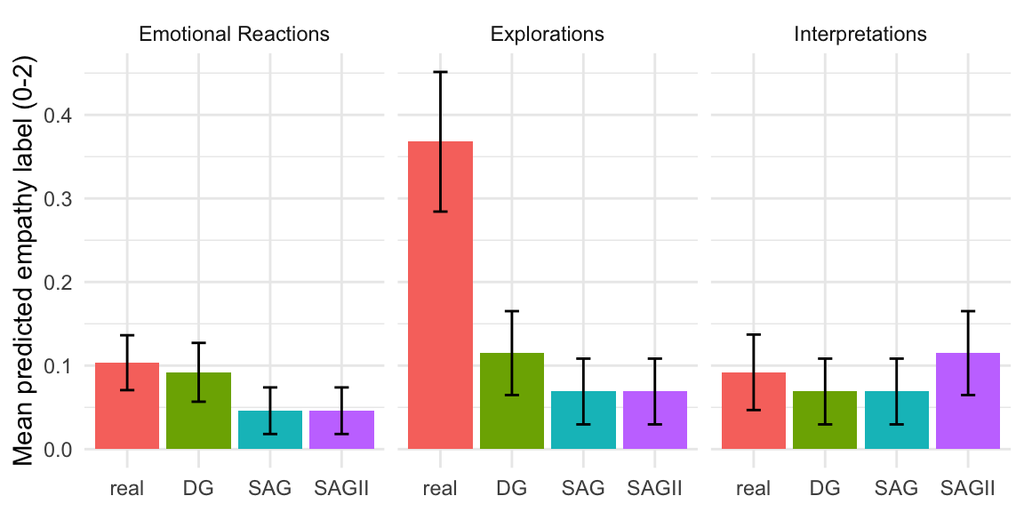

Average predicted empathy per population.

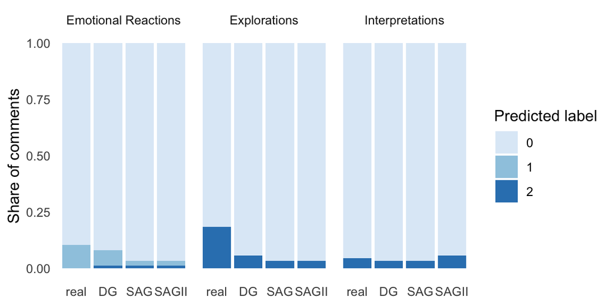

Stacked predicted label proportions per population.

## Real vs. synthetic (Mann-Whitney U, Benjamini-Hochberg adjusted)

Mann-Whitney U test.

| Mechanism | Method | Mean (real) | Mean (synthetic) | p | p (BH-adj.) | Rank-biserial r |
| --- | --- | --- | --- | --- | --- | --- |
| Emotional Reactions | DG | 0.103 | 0.092 | 0.6220 | 0.7358 | 0.022 |
| Emotional Reactions | SAG | 0.103 | 0.046 | 0.0792 | 0.1426 | 0.068 |
| Emotional Reactions | SAGII | 0.103 | 0.046 | 0.0792 | 0.1426 | 0.068 |
| Interpretations | DG | 0.092 | 0.069 | 0.7037 | 0.7358 | 0.011 |
| Interpretations | SAG | 0.092 | 0.069 | 0.7037 | 0.7358 | 0.011 |
| Interpretations | SAGII | 0.092 | 0.115 | 0.7358 | 0.7358 | -0.011 |
| Explorations | DG | 0.368 | 0.115 | 0.0108 | 0.0323 | 0.126 |
| Explorations | SAG | 0.368 | 0.069 | 0.0016 | 0.0074 | 0.149 |
| Explorations | SAGII | 0.368 | 0.069 | 0.0016 | 0.0074 | 0.149 |

Kruskal-Wallis Test.

| Mechanism | H | p (Kruskal-Wallis) |
| --- | --- | --- |
| Emotional Reactions | 5.05 | 0.1683 |
| Interpretations | 0.76 | 0.8580 |
| Explorations | 18.70 | 0.0003 |

Across the 3 empathy mechanisms, 3 of the 9 real-vs-synthetic comparisons were significant after BH correction at $\alpha = .05$ (see Table $\ref{tab:mwu}$):

**Emotional Reactions:** no synthetic method differed significantly from real comments after correction.

**Interpretations:** no synthetic method differed significantly from real comments after correction.

**Explorations:** DG scored lower than real (p_adj = 0.0323, r = 0.13); SAG scored lower than real (p_adj = 0.0074, r = 0.15); SAGII scored lower than real (p_adj = 0.0074, r = 0.15).

The clearest and only consistent gap is in **Explorations** (Kruskal-Wallis p = 0.00032; see $\ref{tab:kw}$): every synthetic method scored lower than real comments, by an average factor of 4.6x.

## Comment length

Real comments (mean 42 words, median 29, SD 44) are on average 6 words longer than synthetic comments and more variable in length. Synthetic comments are tightly clustered around 36 words (SD 8) regardless of method, suggesting the generation prompts constrain length fairly strictly.

| Group | n | Mean length | Median length | SD length |
| --- | --- | --- | --- | --- |
| real | 87 | 41.8 | 29 | 43.9 |
| DG | 87 | 38.2 | 38 | 8.9 |
| SAG | 87 | 34.5 | 34 | 7.2 |
| SAGII | 87 | 34.9 | 34 | 7.6 |

| Mechanism | Group | n | Spearman rho | p | p (BH-adj.) |
| --- | --- | --- | --- | --- | --- |
| Emotional Reactions | overall | 348 | 0.130 | 0.0155 | 0.1163 |
| Emotional Reactions | real | 87 | 0.303 | 0.0043 | 0.0652 |
| Emotional Reactions | DG | 87 | -0.017 | 0.8785 | 0.8785 |
| Emotional Reactions | SAG | 87 | -0.018 | 0.8691 | 0.8785 |
| Emotional Reactions | SAGII | 87 | 0.086 | 0.4303 | 0.6943 |
| Interpretations | overall | 348 | 0.101 | 0.0610 | 0.1829 |
| Interpretations | real | 87 | 0.141 | 0.1927 | 0.3613 |
| Interpretations | DG | 87 | 0.164 | 0.1280 | 0.3070 |
| Interpretations | SAG | 87 | 0.036 | 0.7377 | 0.8785 |
| Interpretations | SAGII | 87 | 0.080 | 0.4629 | 0.6943 |
| Explorations | overall | 348 | -0.113 | 0.0352 | 0.1375 |
| Explorations | real | 87 | -0.032 | 0.7692 | 0.8785 |
| Explorations | DG | 87 | -0.224 | 0.0367 | 0.1375 |
| Explorations | SAG | 87 | -0.158 | 0.1433 | 0.3070 |
| Explorations | SAGII | 87 | 0.069 | 0.5251 | 0.7160 |

0 of the 15 length-empathy correlations (overall and within each group, per mechanism) are significant after BH correction: none. Length is not a strong general driver of predicted empathy: most correlations are weak and non-significant, including every pooled (“overall”) correlation. Hence, the group differences reported above are unlikely to be a simple length artifact, even though real and synthetic comments differ somewhat in length.